# R Flight Data EDA

Ewan Mitchell

```r
library(readr)
library(dplyr)       # For data manipulation
```

```r
library(ggplot2)     # For data visualization
library(summarytools) # For summary statistics
library(ggplot2)
library(tidyr)
library(knitr)
library(maps)
library(mapdata)
library(corrplot)
library(factoextra)
library(RColorBrewer)
```

## 2019 Airline Delays with Weather and Airport Detail

This data set is about flight delays in the United States, providing detailed information about airline, weather, airport and employment conditions. The aim of exploring this data set is to study the correlation between features and flight delays with the eventual goal, in Assessment 1, of performing a binary classification on this data set.

Data set available at “https://www.kaggle.com/datasets/threnjen/2019-airline-delays-and-cancellations”.

```r
flightData <- read_csv("C:/Users/USER/OneDrive/Bristol Year 4/Data Science Toolbox/Group Assessments/full_data_flightdelay.csv")
```

We present the features of the data set.

```r
colnames(flightData)
```

```
##  [1] "MONTH"                         "DAY_OF_WEEK"
##  [3] "DEP_DEL15"                     "DEP_TIME_BLK"
##  [5] "DISTANCE_GROUP"                "SEGMENT_NUMBER"
##  [7] "CONCURRENT_FLIGHTS"            "NUMBER_OF_SEATS"
##  [9] "CARRIER_NAME"                  "AIRPORT_FLIGHTS_MONTH"
## [11] "AIRLINE_FLIGHTS_MONTH"         "AIRLINE_AIRPORT_FLIGHTS_MONTH"
## [13] "AVG_MONTHLY_PASS_AIRPORT"      "AVG_MONTHLY_PASS_AIRLINE"
## [15] "FLT_ATTENDANTS_PER_PASS"       "GROUND_SERV_PER_PASS"
## [17] "PLANE_AGE"                     "DEPARTING_AIRPORT"
## [19] "LATITUDE"                      "LONGITUDE"
## [21] "PREVIOUS_AIRPORT"              "PRCP"
## [23] "SNOW"                          "SNWD"
## [25] "TMAX"                          "AWND"
```

```r
column_descriptions <- data.frame(
  Variable = c(
    "MONTH", "DAY_OF_WEEK", "DEP_DEL15", "DEP_TIME_BLK", "DISTANCE_GROUP",
    "SEGMENT_NUMBER", "CONCURRENT_FLIGHTS", "NUMBER_OF_SEATS", "CARRIER_NAME",
    "AIRPORT_FLIGHTS_MONTH", "AIRLINE_FLIGHTS_MONTH", "AIRLINE_AIRPORT_FLIGHTS_MONTH",
    "AVG_MONTHLY_PASS_AIRPORT", "AVG_MONTHLY_PASS_AIRLINE", "FLT_ATTENDANTS_PER_PASS",
    "GROUND_SERV_PER_PASS", "PLANE_AGE", "DEPARTING_AIRPORT", "LATITUDE",
    "LONGITUDE", "PREVIOUS_AIRPORT", "PRCP", "SNOW", "SNWD", "TMAX", "AWND"
  ),
  Description = c(
    "Month", "Day of Week", "(TARGET) Departure Delay Indicator, 15 Minutes or More (1=Yes)",
    "CRS Departure Time Block, Hourly Intervals", "Distance group to be flown by departing aircraft",
    "The segment that this tail number is on for the day", "Concurrent flights leaving from the airport in the same departure block",
    "Number of seats on the aircraft", "Carrier", "Avg Airport Flights per Month",
    "Avg Airline Flights per Month", "Avg Flights per month for Airline AND Airport",
    "Avg Passengers for the departing airport for the month", "Avg Passengers for airline for month",
    "Flight attendants per passenger for airline", "Ground service employees (service desk) per passenger for airline",
    "Age of departing aircraft", "Departing Airport", "Latitude of departing airport",
    "Longitude of departing airport", "Previous airport that aircraft departed from",
    "Inches of precipitation for day", "Inches of snowfall for day",
    "Inches of snow on ground for day", "Max temperature for day", "Max wind speed for day"
  )
)

kable(column_descriptions, format = "html", caption = "Column Descriptions")
```

Column Descriptions

| Variable | Description |
| --- | --- |
| MONTH | Month |
| DAY_OF_WEEK | Day of Week |
| DEP_DEL15 | (TARGET) Departure Delay Indicator, 15 Minutes or More (1=Yes) |
| DEP_TIME_BLK | CRS Departure Time Block, Hourly Intervals |
| DISTANCE_GROUP | Distance group to be flown by departing aircraft |
| SEGMENT_NUMBER | The segment that this tail number is on for the day |
| CONCURRENT_FLIGHTS | Concurrent flights leaving from the airport in the same departure block |
| NUMBER_OF_SEATS | Number of seats on the aircraft |
| CARRIER_NAME | Carrier |
| AIRPORT_FLIGHTS_MONTH | Avg Airport Flights per Month |
| AIRLINE_FLIGHTS_MONTH | Avg Airline Flights per Month |
| AIRLINE_AIRPORT_FLIGHTS_MONTH | Avg Flights per month for Airline AND Airport |
| AVG_MONTHLY_PASS_AIRPORT | Avg Passengers for the departing airport for the month |
| AVG_MONTHLY_PASS_AIRLINE | Avg Passengers for airline for month |
| FLT_ATTENDANTS_PER_PASS | Flight attendants per passenger for airline |
| GROUND_SERV_PER_PASS | Ground service employees (service desk) per passenger for airline |
| PLANE_AGE | Age of departing aircraft |
| DEPARTING_AIRPORT | Departing Airport |
| LATITUDE | Latitude of departing airport |
| LONGITUDE | Longitude of departing airport |
| PREVIOUS_AIRPORT | Previous airport that aircraft departed from |
| PRCP | Inches of precipitation for day |
| SNOW | Inches of snowfall for day |
| SNWD | Inches of snow on ground for day |
| TMAX | Max temperature for day |
| AWND | Max wind speed for day |

```r
glimpse(flightData)
```

```
## Rows: 6,489,062
## Columns: 26
## $ MONTH                         <dbl> 1, 1, 1, 1, 1, 1, 1, 1, 1, 1, 1, 1, 1, 1…
## $ DAY_OF_WEEK                   <dbl> 7, 7, 7, 7, 7, 7, 7, 7, 7, 7, 7, 7, 7, 7…
## $ DEP_DEL15                     <dbl> 0, 0, 0, 0, 0, 0, 0, 1, 0, 0, 1, 0, 0, 0…
## $ DEP_TIME_BLK                  <chr> "0800-0859", "0700-0759", "0600-0659", "…
## $ DISTANCE_GROUP                <dbl> 2, 7, 7, 9, 7, 3, 6, 7, 7, 8, 6, 1, 1, 2…
## $ SEGMENT_NUMBER                <dbl> 1, 1, 1, 1, 1, 1, 1, 1, 1, 1, 1, 1, 1, 1…
## $ CONCURRENT_FLIGHTS            <dbl> 25, 29, 27, 27, 10, 10, 29, 10, 10, 27, …
## $ NUMBER_OF_SEATS               <dbl> 143, 191, 199, 180, 182, 180, 186, 186, …
## $ CARRIER_NAME                  <chr> "Southwest Airlines Co.", "Delta Air Lin…
## $ AIRPORT_FLIGHTS_MONTH         <dbl> 13056, 13056, 13056, 13056, 13056, 13056…
## $ AIRLINE_FLIGHTS_MONTH         <dbl> 107363, 73508, 73508, 73508, 15023, 9496…
## $ AIRLINE_AIRPORT_FLIGHTS_MONTH <dbl> 5873, 1174, 1174, 1174, 1257, 581, 581, …
## $ AVG_MONTHLY_PASS_AIRPORT      <dbl> 1903352, 1903352, 1903352, 1903352, 1903…
## $ AVG_MONTHLY_PASS_AIRLINE      <dbl> 13382999, 12460183, 12460183, 12460183, …
## $ FLT_ATTENDANTS_PER_PASS       <dbl> 6.178236e-05, 1.441659e-04, 1.441659e-04…
## $ GROUND_SERV_PER_PASS          <dbl> 9.889412e-05, 1.486602e-04, 1.486602e-04…
## $ PLANE_AGE                     <dbl> 8, 3, 18, 2, 1, 5, 2, 3, 3, 1, 3, 3, 12,…
## $ DEPARTING_AIRPORT             <chr> "McCarran International", "McCarran Inte…
## $ LATITUDE                      <dbl> 36.08, 36.08, 36.08, 36.08, 36.08, 36.08…
## $ LONGITUDE                     <dbl> -115.152, -115.152, -115.152, -115.152, …
## $ PREVIOUS_AIRPORT              <chr> "NONE", "NONE", "NONE", "NONE", "NONE", …
## $ PRCP                          <dbl> 0, 0, 0, 0, 0, 0, 0, 0, 0, 0, 0, 0, 0, 0…
## $ SNOW                          <dbl> 0, 0, 0, 0, 0, 0, 0, 0, 0, 0, 0, 0, 0, 0…
## $ SNWD                          <dbl> 0, 0, 0, 0, 0, 0, 0, 0, 0, 0, 0, 0, 0, 0…
## $ TMAX                          <dbl> 65, 65, 65, 65, 65, 65, 65, 65, 65, 65, …
## $ AWND                          <dbl> 2.91, 2.91, 2.91, 2.91, 2.91, 2.91, 2.91…
```

```r
head(flightData)
```

| MONTH | DAY_OF_WEEK | DEP_DEL15 | DEP_TIME_BLK | DISTANCE_GROUP | SEGMENT_NUMBER | CONCURRENT_FLIGHTS | NUMBER_OF_SEATS | CARRIER_NAME | AIRPORT_FLIGHTS_MONTH | AIRLINE_FLIGHTS_MONTH | AIRLINE_AIRPORT_FLIGHTS_MONTH | AVG_MONTHLY_PASS_AIRPORT | AVG_MONTHLY_PASS_AIRLINE | FLT_ATTENDANTS_PER_PASS | GROUND_SERV_PER_PASS | PLANE_AGE | DEPARTING_AIRPORT | LATITUDE | LONGITUDE | PREVIOUS_AIRPORT | PRCP | SNOW | SNWD | TMAX | AWND |
| --- | --- | --- | --- | --- | --- | --- | --- | --- | --- | --- | --- | --- | --- | --- | --- | --- | --- | --- | --- | --- | --- | --- | --- | --- | --- |
| 1 | 7 | 0 | 0800-0859 | 2 | 1 | 25 | 143 | Southwest Airlines Co. | 13056 | 107363 | 5873 | 1903352 | 13382999 | 6.178236e-05 | 9.889412e-05 | 8 | McCarran International | 36.08 | -115.152 | NONE | 0 | 0 | 0 | 65 | 2.91 |
| 1 | 7 | 0 | 0700-0759 | 7 | 1 | 29 | 191 | Delta Air Lines Inc. | 13056 | 73508 | 1174 | 1903352 | 12460183 | 1.441659e-04 | 1.486602e-04 | 3 | McCarran International | 36.08 | -115.152 | NONE | 0 | 0 | 0 | 65 | 2.91 |
| 1 | 7 | 0 | 0600-0659 | 7 | 1 | 27 | 199 | Delta Air Lines Inc. | 13056 | 73508 | 1174 | 1903352 | 12460183 | 1.441659e-04 | 1.486602e-04 | 18 | McCarran International | 36.08 | -115.152 | NONE | 0 | 0 | 0 | 65 | 2.91 |
| 1 | 7 | 0 | 0600-0659 | 9 | 1 | 27 | 180 | Delta Air Lines Inc. | 13056 | 73508 | 1174 | 1903352 | 12460183 | 1.441659e-04 | 1.486602e-04 | 2 | McCarran International | 36.08 | -115.152 | NONE | 0 | 0 | 0 | 65 | 2.91 |
| 1 | 7 | 0 | 0001-0559 | 7 | 1 | 10 | 182 | Spirit Air Lines | 13056 | 15023 | 1257 | 1903352 | 2688839 | 9.173724e-06 | 1.246511e-04 | 1 | McCarran International | 36.08 | -115.152 | NONE | 0 | 0 | 0 | 65 | 2.91 |
| 1 | 7 | 0 | 0001-0559 | 3 | 1 | 10 | 180 | Frontier Airlines Inc. | 13056 | 9496 | 581 | 1903352 | 1857122 | 1.157256e-04 | 7.134695e-06 | 5 | McCarran International | 36.08 | -115.152 | NONE | 0 | 0 | 0 | 65 | 2.91 |

```r
summary(flightData)
```

```
##      MONTH         DAY_OF_WEEK      DEP_DEL15      DEP_TIME_BLK
##  Min.   : 1.000   Min.   :1.000   Min.   :0.0000   Length:6489062
##  1st Qu.: 4.000   1st Qu.:2.000   1st Qu.:0.0000   Class :character
##  Median : 7.000   Median :4.000   Median :0.0000   Mode  :character
##  Mean   : 6.607   Mean   :3.936   Mean   :0.1891
##  3rd Qu.:10.000   3rd Qu.:6.000   3rd Qu.:0.0000
##  Max.   :12.000   Max.   :7.000   Max.   :1.0000
##  DISTANCE_GROUP   SEGMENT_NUMBER   CONCURRENT_FLIGHTS NUMBER_OF_SEATS
##  Min.   : 1.000   Min.   : 1.000   Min.   :  1.00     Min.   : 44.0
##  1st Qu.: 2.000   1st Qu.: 2.000   1st Qu.: 11.00     1st Qu.: 90.0
##  Median : 3.000   Median : 3.000   Median : 23.00     Median :143.0
##  Mean   : 3.821   Mean   : 3.047   Mean   : 27.84     Mean   :133.7
##  3rd Qu.: 5.000   3rd Qu.: 4.000   3rd Qu.: 39.00     3rd Qu.:172.0
##  Max.   :11.000   Max.   :15.000   Max.   :109.00     Max.   :337.0
##  CARRIER_NAME       AIRPORT_FLIGHTS_MONTH AIRLINE_FLIGHTS_MONTH
##  Length:6489062     Min.   : 1100         Min.   :  5582
##  Class :character   1st Qu.: 5345         1st Qu.: 25034
##  Mode  :character   Median :11562         Median : 70878
##                     Mean   :12685         Mean   : 62961
##                     3rd Qu.:17615         3rd Qu.: 86312
##                     Max.   :35256         Max.   :117728
##  AIRLINE_AIRPORT_FLIGHTS_MONTH AVG_MONTHLY_PASS_AIRPORT
##  Min.   :    1                 Min.   :  70476
##  1st Qu.:  654                 1st Qu.: 673221
##  Median : 2251                 Median :1486066
##  Mean   : 3459                 Mean   :1588639
##  3rd Qu.: 4806                 3rd Qu.:2006675
##  Max.   :21837                 Max.   :4365661
##  AVG_MONTHLY_PASS_AIRLINE FLT_ATTENDANTS_PER_PASS GROUND_SERV_PER_PASS
##  Min.   :  473794         Min.   :0.000e+00       Min.   :7.135e-06
##  1st Qu.: 2688839         1st Qu.:3.419e-05       1st Qu.:9.889e-05
##  Median : 8501631         Median :6.178e-05       Median :1.247e-04
##  Mean   : 7814970         Mean   :9.754e-05       Mean   :1.356e-04
##  3rd Qu.:12460183         3rd Qu.:1.442e-04       3rd Qu.:1.773e-04
##  Max.   :13382999         Max.   :3.484e-04       Max.   :2.290e-04
##    PLANE_AGE     DEPARTING_AIRPORT     LATITUDE       LONGITUDE
##  Min.   : 0.00   Length:6489062     Min.   :18.44   Min.   :-159.35
##  1st Qu.: 5.00   Class :character   1st Qu.:33.44   1st Qu.:-106.38
##  Median :12.00   Mode  :character   Median :37.51   Median : -87.91
##  Mean   :11.53                      Mean   :36.71   Mean   : -94.26
##  3rd Qu.:17.00                      3rd Qu.:40.78   3rd Qu.: -80.94
##  Max.   :32.00                      Max.   :61.17   Max.   : -66.00
##  PREVIOUS_AIRPORT        PRCP              SNOW               SNWD
##  Length:6489062     Min.   : 0.0000   Min.   : 0.00000   Min.   : 0.00000
##  Class :character   1st Qu.: 0.0000   1st Qu.: 0.00000   1st Qu.: 0.00000
##  Mode  :character   Median : 0.0000   Median : 0.00000   Median : 0.00000
##                     Mean   : 0.1037   Mean   : 0.03159   Mean   : 0.09152
##                     3rd Qu.: 0.0200   3rd Qu.: 0.00000   3rd Qu.: 0.00000
##                     Max.   :11.6300   Max.   :17.20000   Max.   :25.20000
##       TMAX             AWND
##  Min.   :-10.00   Min.   : 0.000
##  1st Qu.: 59.00   1st Qu.: 5.820
##  Median : 74.00   Median : 7.830
##  Mean   : 71.47   Mean   : 8.341
##  3rd Qu.: 86.00   3rd Qu.:10.290
##  Max.   :115.00   Max.   :33.780
```

```r
missing_values <- flightData %>%
  summarise_all(~ sum(is.na(.)))

missing_values
```

| MONTH | DAY_OF_WEEK | DEP_DEL15 | DEP_TIME_BLK | DISTANCE_GROUP | SEGMENT_NUMBER | CONCURRENT_FLIGHTS | NUMBER_OF_SEATS | CARRIER_NAME | AIRPORT_FLIGHTS_MONTH | AIRLINE_FLIGHTS_MONTH | AIRLINE_AIRPORT_FLIGHTS_MONTH | AVG_MONTHLY_PASS_AIRPORT | AVG_MONTHLY_PASS_AIRLINE | FLT_ATTENDANTS_PER_PASS | GROUND_SERV_PER_PASS | PLANE_AGE | DEPARTING_AIRPORT | LATITUDE | LONGITUDE | PREVIOUS_AIRPORT | PRCP | SNOW | SNWD | TMAX | AWND |
| --- | --- | --- | --- | --- | --- | --- | --- | --- | --- | --- | --- | --- | --- | --- | --- | --- | --- | --- | --- | --- | --- | --- | --- | --- | --- |
| 0 | 0 | 0 | 0 | 0 | 0 | 0 | 0 | 0 | 0 | 0 | 0 | 0 | 0 | 0 | 0 | 0 | 0 | 0 | 0 | 0 | 0 | 0 | 0 | 0 | 0 |

### Examining the proportion of delays by carrier.

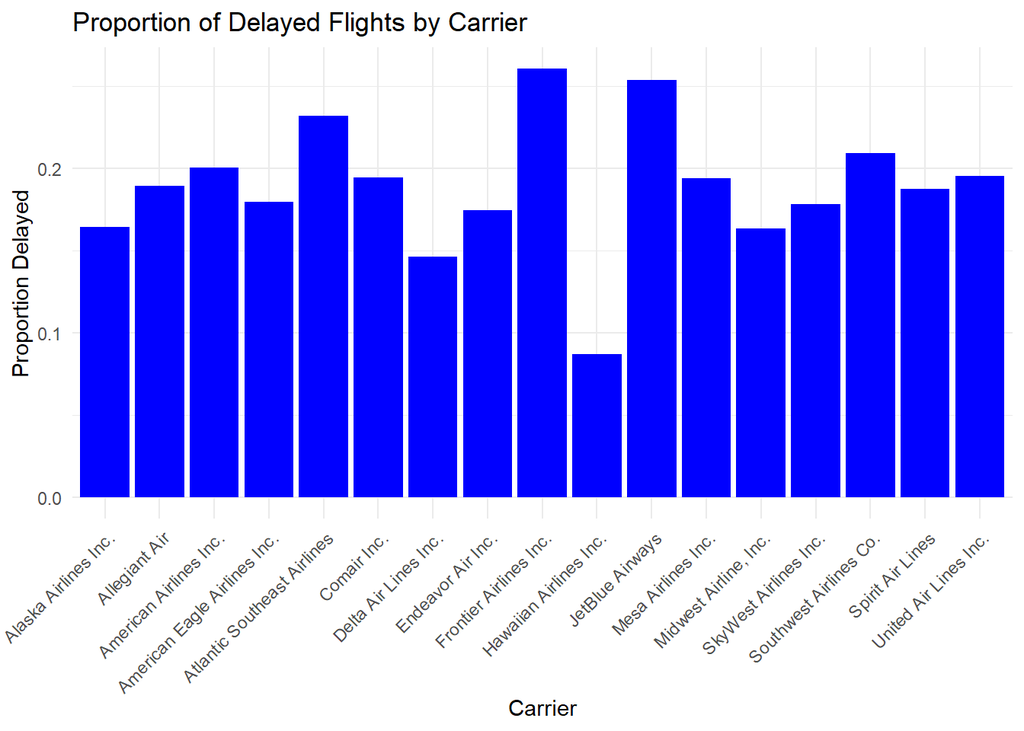

```r
# Bar chart of carrier vs proportion of delays
delayed_proportions <- flightData %>%
  group_by(CARRIER_NAME) %>%
  summarize(proportion_delayed = mean(DEP_DEL15 == 1))

ggplot(delayed_proportions, aes(x = CARRIER_NAME, y = proportion_delayed)) +
  geom_bar(stat = "identity", fill = "blue") +
  labs(
    title = "Proportion of Delayed Flights by Carrier",
    x = "Carrier",
    y = "Proportion Delayed"
  ) +
  theme_minimal() +
  theme(axis.text.x = element_text(angle = 45, hjust = 1))
```

We see that “Frontier Airlines” and “JetBlue Airways” have the highest proportions of delayed flights, while “Hawaiian Airlines” has the lowest.

### Examining the proportion of delays by month of the year.

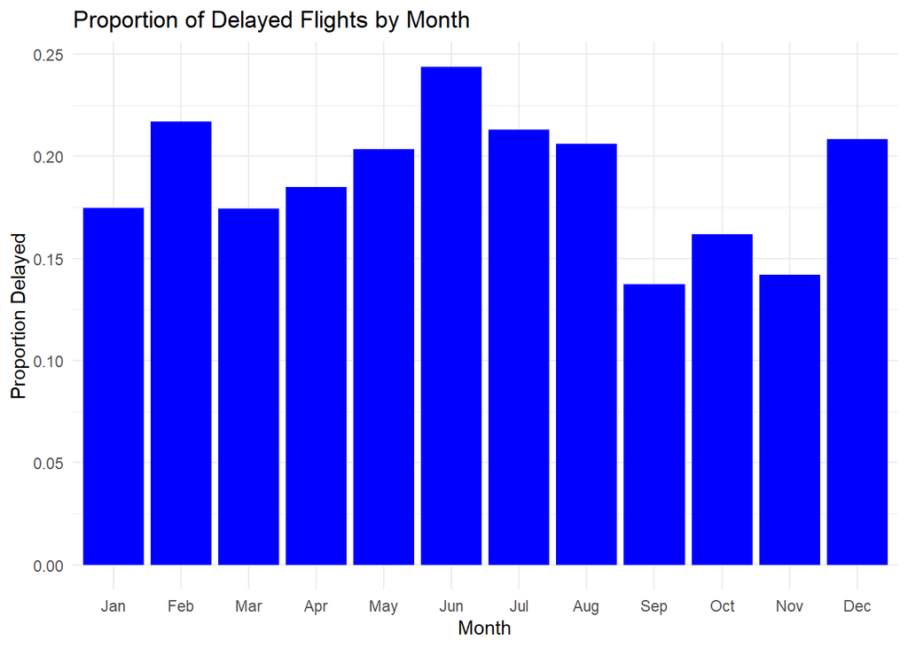

```r
delayed_proportions <- flightData %>%
  group_by(MONTH) %>%
  summarize(proportion_delayed = mean(DEP_DEL15 == 1))

#flightData$MONTH <- factor(flightData$MONTH, levels = month.abb)

ggplot(delayed_proportions, aes(x = MONTH, y = proportion_delayed)) +
  geom_bar(stat = "identity", fill = "blue") +
  labs(
    title = "Proportion of Delayed Flights by Month",
    x = "Month",
    y = "Proportion Delayed"
  ) +
  theme_minimal() +
 scale_x_discrete(limits = month.abb)
```

We can observe a small peak at June, which could be due to the start of the holiday season., while September and November have the lowest - which are typically not holiday months.

### Examining the proportion of delays by day of the week.

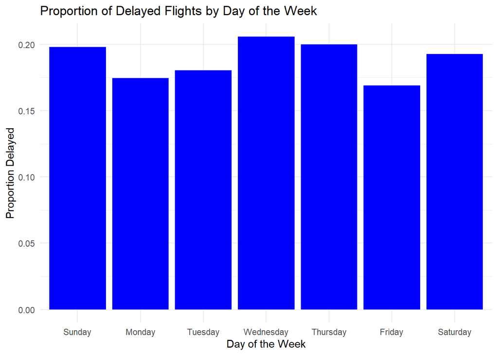

```r
delayed_proportions <- flightData %>%
  group_by(DAY_OF_WEEK) %>%
  summarize(proportion_delayed = mean(DEP_DEL15 == 1))

day_order <- c("Sunday", "Monday", "Tuesday", "Wednesday", "Thursday", "Friday", "Saturday")

#flightData$DAY_OF_WEEK <- factor(flightData$DAY_OF_WEEK, levels = day_order)

ggplot(delayed_proportions, aes(x = DAY_OF_WEEK, y = proportion_delayed)) +
  geom_bar(stat = "identity", fill = "blue") +
  labs(
    title = "Proportion of Delayed Flights by Day of the Week",
    x = "Day of the Week",
    y = "Proportion Delayed"
  ) +
  theme_minimal() +
  scale_x_discrete(limits = day_order)
```

The appears to only be slight variation between days of the week.

### Examining the number of flights by departure time block.

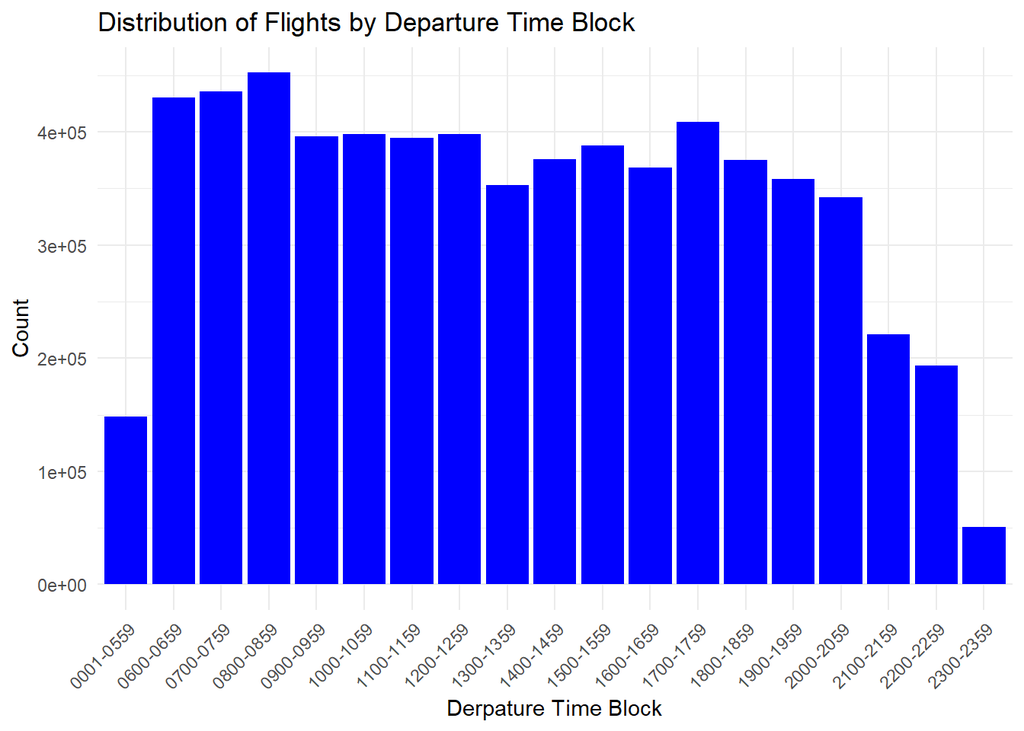

```r
# Histogram of DEP_TIME_BLK
ggplot(flightData, aes(x = DEP_TIME_BLK)) +
  geom_bar(fill = "blue") +
  labs(
    title = "Distribution of Flights by Departure Time Block",
    x = "Derpature Time Block",
    y = "Count"
  ) +
  theme_minimal() +
  theme(axis.text.x = element_text(angle = 45, hjust = 1))
```

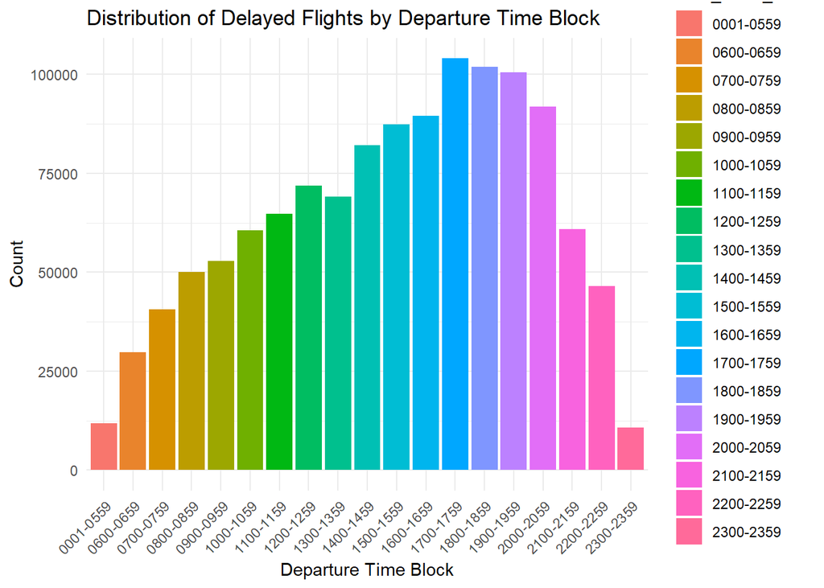

```r
delayed_flights <- flightData %>%
  filter(DEP_DEL15 == 1)

# Create a histogram of DEP_TIME_BLK for delayed flights
ggplot(delayed_flights, aes(x = DEP_TIME_BLK, fill = DEP_TIME_BLK)) +
  geom_bar() +
  labs(
    title = "Distribution of Delayed Flights by Departure Time Block",
    x = "Departure Time Block",
    y = "Count"
  ) +
  theme_minimal() +
  theme(axis.text.x = element_text(angle = 45, hjust = 1))
```

### Density plot of Departing Airplorts with Delayed flights

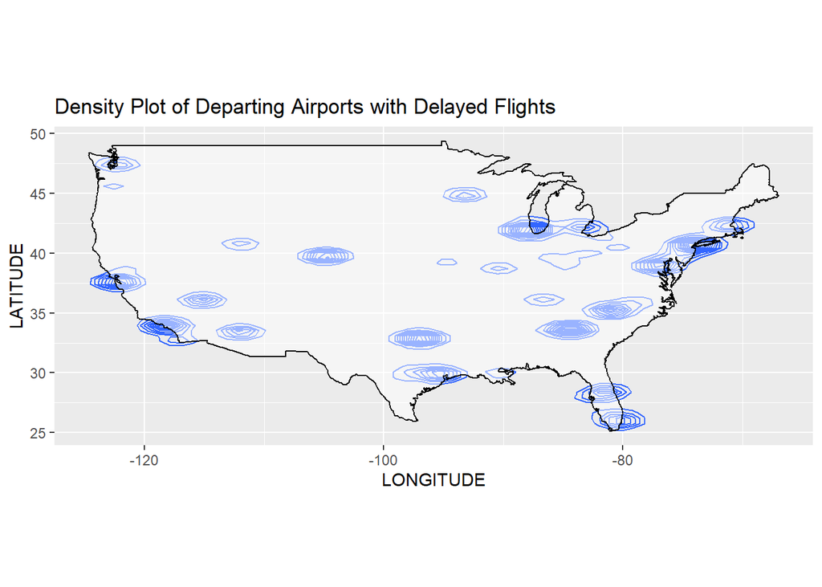

```r
us_map <- map_data("usa") # map of the US

map_plot <- ggplot() +
  geom_polygon(data = us_map, aes(x = long, y = lat, group = group), fill = NA, color = "black", alpha = 0.5) +
  coord_fixed(ratio = 1)   # Ensure aspect ratio is 1:1

ggplot(delayed_flights, aes(x = LONGITUDE, y = LATITUDE)) +
  geom_density_2d() +
  coord_fixed(ratio = 1) +  # Ensure aspect ratio is 1:1
  labs(title = "Density Plot of Departing Airports with Delayed Flights") +
  geom_polygon(data = us_map, aes(x = long, y = lat, group = group), fill = "white", color = "black", alpha = 0.5)
```

```r
# (slow)
```

We see that there are hot spots particularly in the east coast and west coast experiencing the highets density of flight delays.

### Examining the proportion of delayed flights by departing airport

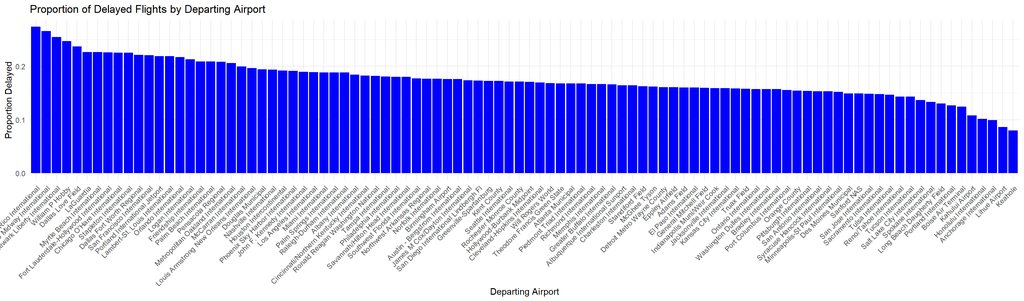

```r
# Calculate the count of delayed flights by departing airport
delayed_counts <- delayed_flights %>%
  group_by(DEPARTING_AIRPORT) %>%
  summarize(delayed_count = n())

total_counts <- flightData %>%
  group_by(DEPARTING_AIRPORT) %>%
  summarize(total_count = n())

airport_proportions <- left_join(delayed_counts, total_counts, by = "DEPARTING_AIRPORT") %>%
  mutate(proportion_delayed = delayed_count / total_count) %>%
  arrange(desc(proportion_delayed))

ggplot(airport_proportions, aes(x = reorder(DEPARTING_AIRPORT, -proportion_delayed), y = proportion_delayed)) +
  geom_bar(stat = "identity", fill = "blue") +
  labs(
    title = "Proportion of Delayed Flights by Departing Airport",
    x = "Departing Airport",
    y = "Proportion Delayed"
  ) +
  theme_minimal() +
  theme(axis.text.x = element_text(angle = 45, hjust = 1))
```

We now use two methods to study the upper outliers of this graph.

```r
 # IQR method
iqr <- IQR(airport_proportions$delayed_count)
q3 <- quantile(airport_proportions$delayed_count, 0.75)

upper_bound <- q3 + 1.5 * iqr

outliers <- airport_proportions %>%
  filter(delayed_count > upper_bound)

print(outliers)
```

```
## # A tibble: 7 × 4
##   DEPARTING_AIRPORT            delayed_count total_count proportion_delayed
##   <chr>                                <int>       <int>              <dbl>
## 1 LaGuardia                            37766      166709              0.227
## 2 Chicago O'Hare International         74049      329045              0.225
## 3 Stapleton International              55609      247175              0.225
## 4 Dallas Fort Worth Regional           65497      296449              0.221
## 5 Douglas Municipal                    44958      231855              0.194
## 6 Los Angeles International            41061      217120              0.189
## 7 Atlanta Municipal                    65892      392603              0.168
```

```r
# z-score method

outliers <- airport_proportions %>%
  filter(scale(delayed_count) > 1.96)
print(outliers)
```

```
## # A tibble: 5 × 4
##   DEPARTING_AIRPORT            delayed_count total_count proportion_delayed
##   <chr>                                <int>       <int>              <dbl>
## 1 Chicago O'Hare International         74049      329045              0.225
## 2 Stapleton International              55609      247175              0.225
## 3 Dallas Fort Worth Regional           65497      296449              0.221
## 4 Douglas Municipal                    44958      231855              0.194
## 5 Atlanta Municipal                    65892      392603              0.168
```

### Examining the correlation between airport information + flight delays

We look at only numeric features that concern the departing airport and airline and the flight departures, and perform correlation analysis and PCA.

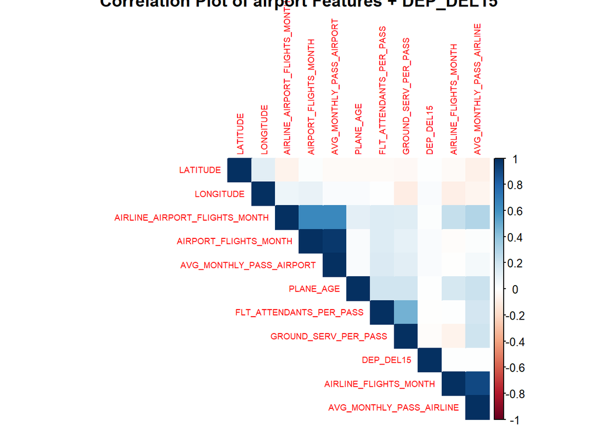

```r
airport_vars <- c(
  "AIRPORT_FLIGHTS_MONTH", "AIRLINE_FLIGHTS_MONTH", "AIRLINE_AIRPORT_FLIGHTS_MONTH",
  "AVG_MONTHLY_PASS_AIRPORT", "AVG_MONTHLY_PASS_AIRLINE",
  "FLT_ATTENDANTS_PER_PASS", "GROUND_SERV_PER_PASS", "PLANE_AGE",
  "LATITUDE", "LONGITUDE", "DEP_DEL15"
)

filtered_data <- flightData %>%
  select(all_of(airport_vars))

corr <- cor(filtered_data)

corrplot(corr, method = "color", type = "upper", order = "hclust", tl.cex = 0.6, title = "Correlation Plot of airport Features + DEP_DEL15")
```

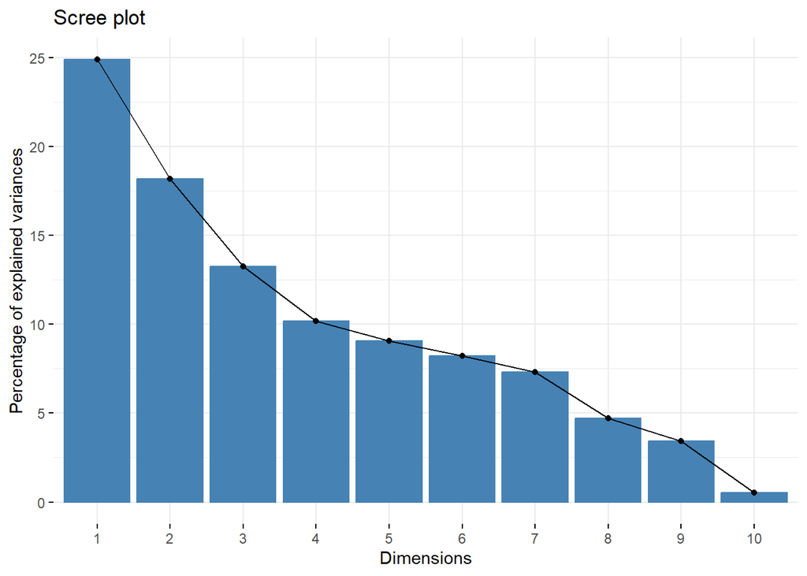

```r
outpca <- prcomp(filtered_data, center = TRUE, scale. = TRUE)

p1 <- fviz_eig(outpca)
p1
```

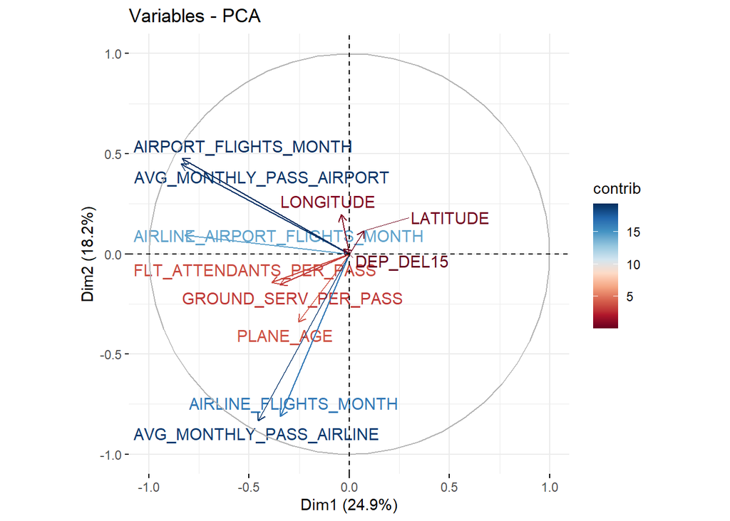

```r
p2 <- fviz_pca_var(outpca,
                   axes = c(1, 2),
                   col.var = "contrib",
                   gradient.cols = brewer.pal(n = 10, name = "RdBu"),
                   repel = TRUE
)
p2
```

We do not observe any strong correlation between the flight delays variable - “DEP_DEL15” and the other variables.

### Examining the correlation between weather information + flight delays

We look at only numeric features that concern the weather and the flight departures, and perform correlation analysis and PCA.

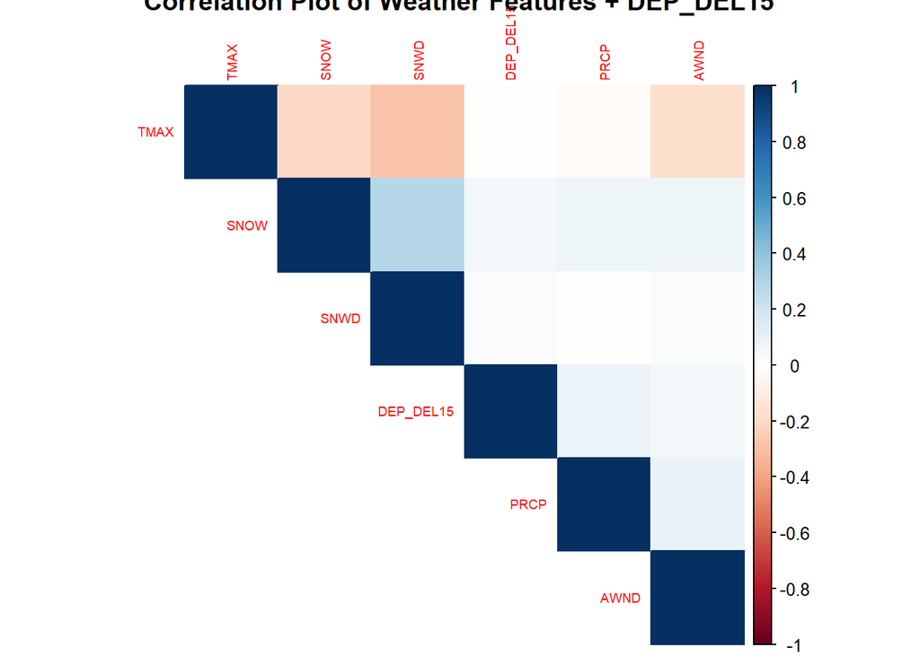

```r
weather_vars <- c("PRCP",   "SNOW", "SNWD", "TMAX", "AWND", "DEP_DEL15")

filtered_data <- flightData %>%
  select(all_of(weather_vars))

corr <- cor(filtered_data)

corrplot(corr, method = "color", type = "upper", order = "hclust", tl.cex = 0.6, title = "Correlation Plot of Weather Features + DEP_DEL15")
```

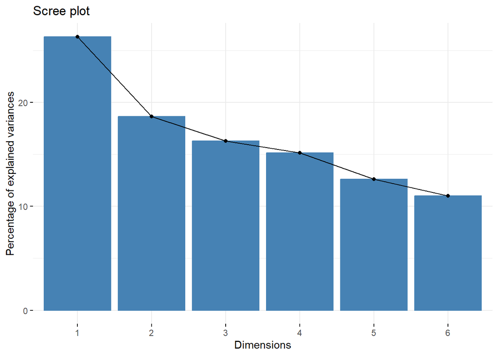

```r
outpca <- prcomp(filtered_data, center = TRUE, scale. = TRUE)

p1 <- fviz_eig(outpca)
p1
```

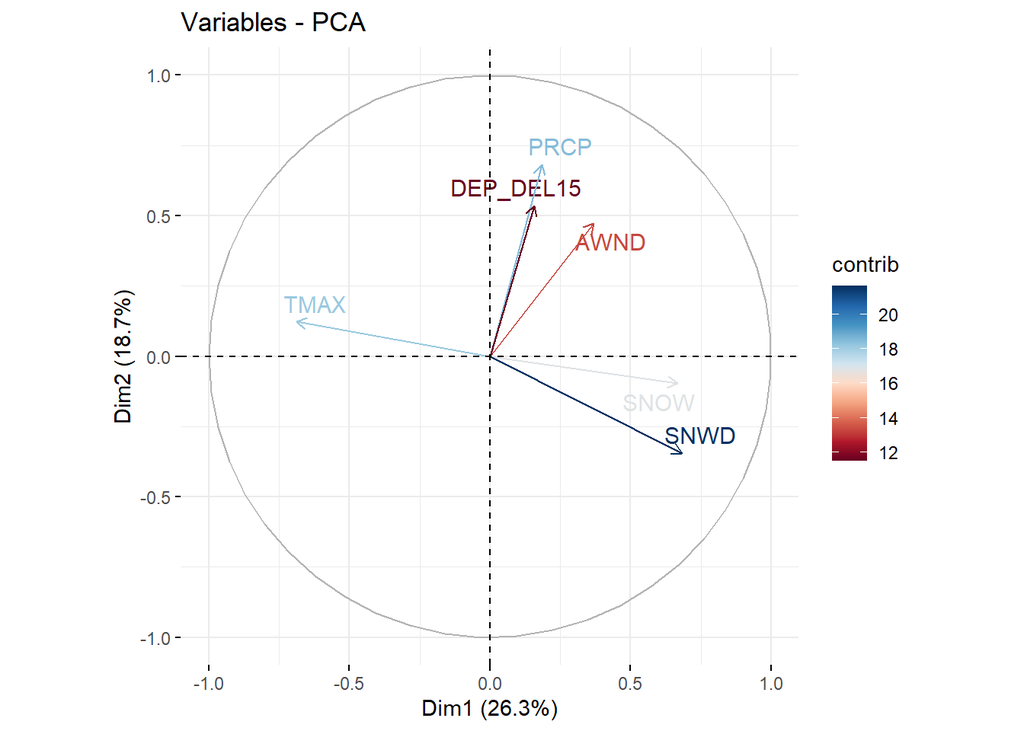

```r
p2 <- fviz_pca_var(outpca,
                   axes = c(1, 2),
                   col.var = "contrib",
                   gradient.cols = brewer.pal(n = 10, name = "RdBu"),
                   repel = TRUE
)
p2
```

For instance, we can clearly observe a positive correlation between “PRCP” - Inches of precipitation for day and flight delays and also a slightly smaller psoitive correlation between “AWND” - max wind speed for day and flight delays.